# EDA w/ Focus on Ratios

Load necessary libraries:

```r
library(tidyverse);
library(crypto);
library(zoo);
```

# Import Data

Import data with `crypto` package using my function `GetCoinHistory()` from the `gatherData.R` file:

```r
data <- GetCoinHistory("ETH")
```

```
Retrieves coin market history from CoinMarketCap.
```

[output not shown]

```
   user  system elapsed
   0.04    0.04    4.58
```

# Organize Data Using my .R Functions

```r
data <- mutateRoll(data,data$open,c(5,10,25))
```

Add Yesterday’s open and close price to data with my function `mutateLast()` from the `mutateData.R` file:

```r
data <- mutateLast(data,data$open,"openLast")
data <- mutateLast(data,data$close,"closeLast")
data <- mutateLast(data,data$high,"highLast")
data <- mutateLast(data,data$low,"lowLast")
data <- mutateLast(data,data$volume,"volumeNext")
```

Add Tomorrow’s open price to data with my function `mutateNext()` from the `mutateData.R` file:

```r
data <- mutateNext(data,data$open,"openNext")
data <- mutateNext(data,data$close,"closeNext")
data <- mutateNext(data,data$high,"highNext")
data <- mutateNext(data,data$low,"lowNext")
data <- mutateNext(data,data$volume,"volumeNext")
```

Now, convert all applicable columns to ratios with my function `convertRatio()` from the `mutateData.R` file:

```r
columnNames <- c("close","low","high","openLast","closeLast","highLast","lowLast","openNext","closeNext","highNext","lowNext","ma1","ma2","ma3")
dataRatio <- convertRatio(data,data$open,columnNames)
```

# Model Evaluation

## Statistical Analysis of Model

**Incomplete, will continue model analysis**

```r
library(boot)
formula <- as.formula("openNext~open+close+ma1")
glm.fit <- glm(formula=formula,data=dataRatio)
glm.fit
```

```
Call:  glm(formula = formula, data = dataRatio)

Coefficients:
  (Intercept)           open          close            ma1
 0.0019557400  -0.0000001335   0.9841390678   0.0143429178

Degrees of Freedom: 1208 Total (i.e. Null);  1205 Residual
  (4 observations deleted due to missingness)
Null Deviance:      5.91
Residual Deviance: 0.03041  AIC: -9363
```

```r
#cv.glm(dataRatio,glm.fit,K=10)$delta
```

## Visualizing Accuracy

The following graph is a visual representation of the accuracy of the model, showing the percentage of predictions within the given percentage of the correct test data value. This was done using my function `glmVect()` in the file `modelData.R`. Note: The function `glmPlot()` in the same file performs the same computations, but saves a .png file of the plot, rather than returning a vector.

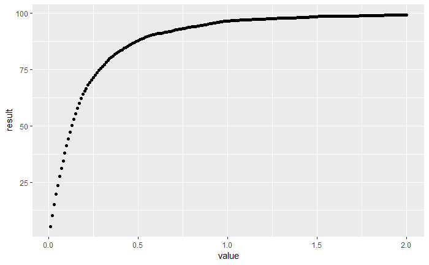

```r
formula <- as.formula("openNext~open+close+volume+high+low+market+ma1+ma2+ma3")
percents <- seq(.01,2,.01)
result <- as.vector(glmVect(1000,200,percents,formula,forNum=100,data1=dataRatio))
ggplot(data=data.frame(result=result,value=percents)) + geom_point(mapping = aes(x=value,y=result))
```